# MECH481A6: Engineering Data Analysis in R

Chapter 4 Homework: Visualizing Ozone Data

Tyson Williams

30 September, 2025

*Note*: If you haven’t installed $LaTex$, change the output mode in the above YAML to `html_document` for ease of knitting and homework submission.

This R Markdown (.Rmd) file is a template for your Chapter 4 Homework. Do everything within this file. Make it your own, but be careful not to change the code-figure-text integration I set up with the code appendix and the global options. If you have used R Markdown before and are comfortable with the extra options, feel free to customize to your heart’s desire. In the end, we will grade the **knitted** PDF or HTML document from within your private GitHub repository. Remember to make regular, small commits (e.g., at least one commit per question) to save your work. We will grade the latest knit, as long as it occurs *before* the start of the class in which we advance to the next chapter. As always, reach out with questions via GitHub Issues or during office hours.

# Ozone data

The corresponding data file (.csv) contains *hourly* ozone data from two sites in Fort Collins. You should already have this file in your `/data` folder.

# Preparation

You completed the following steps in your Chapter 3 Homework. If correct, you should copy-paste the code into this R Markdown document; FYI, you cannot `source()` R Markdown files for use of its output in another file because they are intended to be self-contained and reproducible. Therefore, you need to copy-paste parts of your Chapter 3 Homework into this document and adjust the pathnames, if needed.

## Import, select, and clean data

Recreate the pipe of `dplyr` functions that you used to import the data, select and rename the variables listed below, drop missing observations, and assign the output as a `tibble` (*not in that particular order*).

- `sample_measurement` renamed as `ozone_ppm` (ozone measurement in ppm)
- `datetime` (date in YYYY-MM-DD format and time of measurement in HH:MM:SS)

```
## # A tibble: 16,914 × 3
##    datetime            ozone_ppm ozone_ugm3
##    <dttm>                  <dbl>      <dbl>
##  1 2019-01-01 07:00:00     0.017       36.4
##  2 2019-01-01 08:00:00     0.017       36.4
##  3 2019-01-01 09:00:00     0.017       36.4
##  4 2019-01-01 10:00:00     0.017       36.4
##  5 2019-01-01 11:00:00     0.015       32.1
##  6 2019-01-01 12:00:00     0.017       36.4
##  7 2019-01-01 13:00:00     0.028       60.0
##  8 2019-01-01 14:00:00     0.03        64.2
##  9 2019-01-01 15:00:00     0.036       77.1
## 10 2019-01-01 16:00:00     0.036       77.1
## # ℹ 16,904 more rows
```

## Examine Data

Examine the structure and contents of the dataframe to confirm the file imported and was manipulated properly.

```
##  site_number           latitude       longitude        date_local
##  Length:16914       Min.   :40.58   Min.   :-105.1   Min.   :2019-01-01
##  Class :character   1st Qu.:40.58   1st Qu.:-105.1   1st Qu.:2019-03-30
##  Mode  :character   Median :40.59   Median :-105.1   Median :2019-06-27
##                     Mean   :40.59   Mean   :-105.1   Mean   :2019-06-30
##                     3rd Qu.:40.59   3rd Qu.:-105.1   3rd Qu.:2019-10-03
##                     Max.   :40.59   Max.   :-105.1   Max.   :2019-12-31
##
##    time_local                 datetime                   sample_measurement
##  Min.   :00:00:00.000000   Min.   :2019-01-01 07:00:00   Min.   :0.00000
##  1st Qu.:05:00:00.000000   1st Qu.:2019-03-30 20:15:00   1st Qu.:0.02300
##  Median :12:00:00.000000   Median :2019-06-27 11:30:00   Median :0.03300
##  Mean   :11:30:52.997517   Mean   :2019-07-01 06:01:45   Mean   :0.03305
##  3rd Qu.:18:00:00.000000   3rd Qu.:2019-10-03 21:45:00   3rd Qu.:0.04300
##  Max.   :23:00:00.000000   Max.   :2020-01-01 06:00:00   Max.   :0.09600
##                            NA's   :708
##  units_of_measure   sample_duration       method            ozone_ppm
##  Length:16914       Length:16914       Length:16914       Min.   :0.00000
##  Class :character   Class :character   Class :character   1st Qu.:0.02300
##  Mode  :character   Mode  :character   Mode  :character   Median :0.03300
##                                                           Mean   :0.03305
##                                                           3rd Qu.:0.04300
##                                                           Max.   :0.09600
##
##    ozone_ugm3
##  Min.   :  0.00
##  1st Qu.: 49.25
##  Median : 70.67
##  Mean   : 70.78
##  3rd Qu.: 92.08
##  Max.   :205.58
##
```

# Question 1: `ggplot2` time series

Using `ggplot` and the corresponding `geom`, create a time series of ozone measurement across time. Warning: This plot will have a very poor ink-to-information ratio. Ugly plots are okay when you are just exploring data.

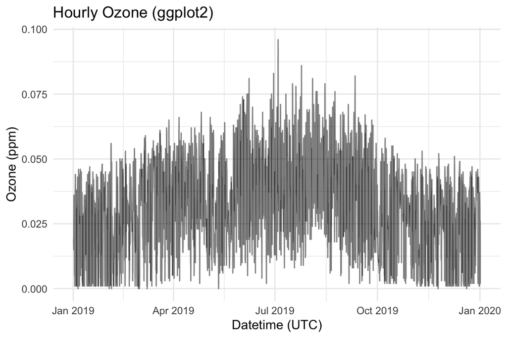

# Question 2: Base R equivalent

For comparison, what function could you use to create a time series of these data in base R? How does the syntax of this function compare to that of `ggplot()`?

You can use base R and functions like plotting (plot(), lines(), points()). These are different compared to the ones I used above that come from ggplot.

# Question 3: `ggplot` object

Excluding the geom, assign the plot from Question 1 as a `ggplot` object with a descriptive name.

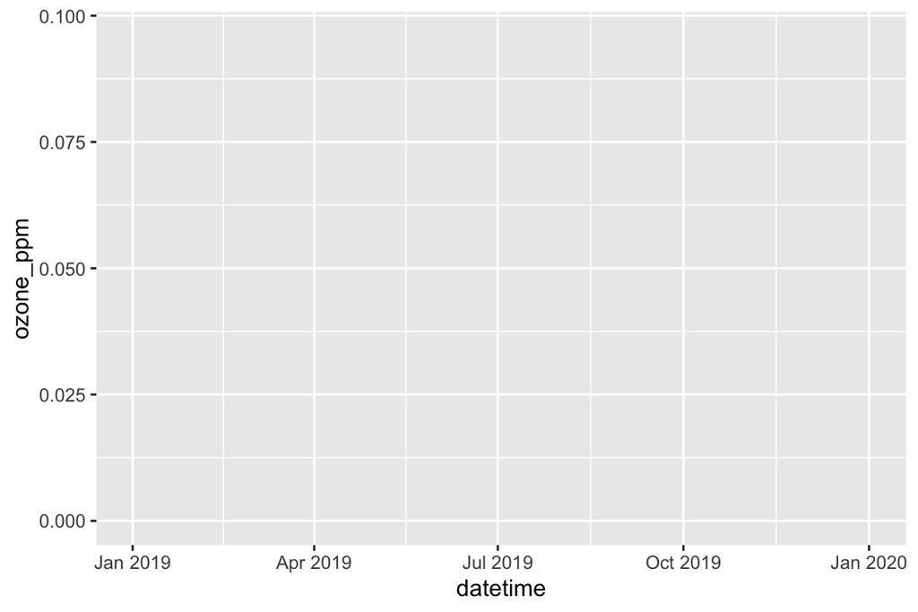

# Question 4: `geom`

Now, `geom_point()` to the `ggplot` object using the following syntax: `object_name + geom_point()`. Remember, you have already defined the `aes()` in the `ggplot` object in Question 3.

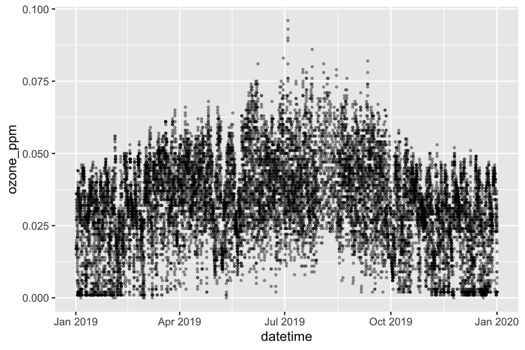

# Question 5: `ggplot` layers

Call and examine object within the R Markdown, Console, or using View. How many layers does this `ggplot` object contain? Why?

Used length to find that it. Layers is 1. There is one layer because we only added a single geom

# Question 6: theme

Next, add the `ggplot2` theme of your choice to the `ggplot` object with `theme_*()` function prefix.

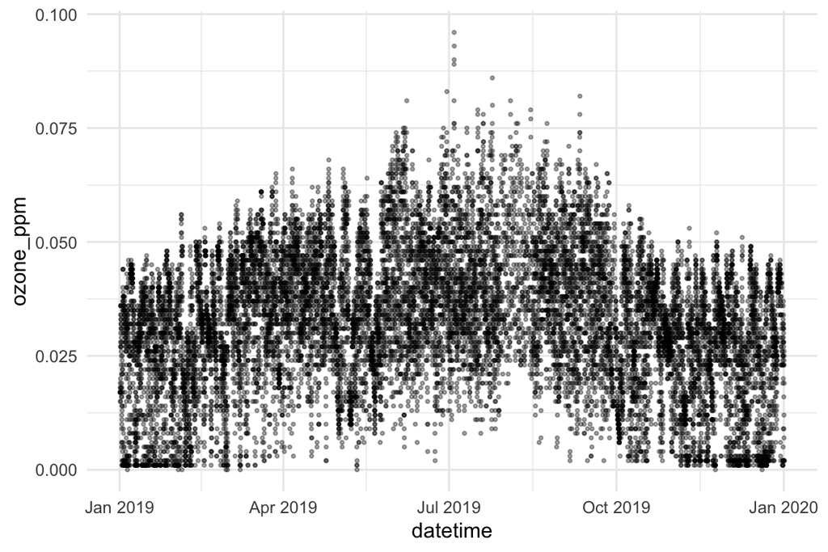

# Question 7: additions

In addition to assigning a plot as a `ggplot` object, one can also assign aspects of the figure such as axis labels and titles to an object for later use. For example:

Using this technique and the same additive approach (`ggplot_object + ... + title`) from Questions 5 and 6, add a title and revise the axis labels.

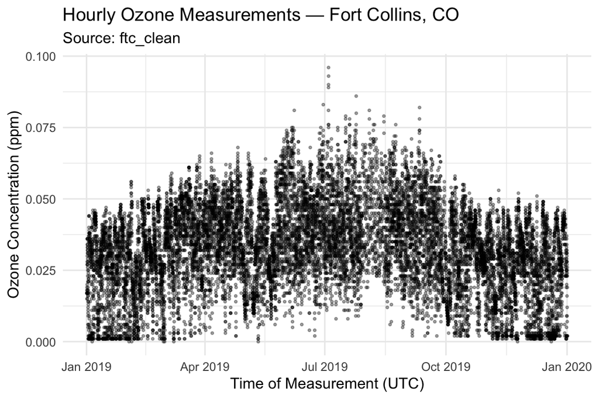

# Question 7: ways to see more granularity

The time series from the previous questions does not look nice. It is hard to discern granular patterns in the data because of their sheer density; there are too many hourly measurements over time. We could look at the data on different time scales, but, because we have not discussed how to manipulate dates and times, we will instead focus first on adding transparency to the data points using the `alpha =` aesthetic. Try recreating the time-series plot with `alpha = 0.2`.

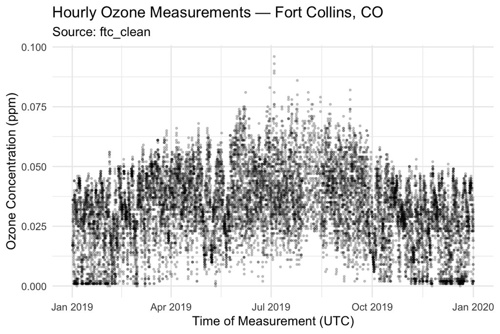

Alternatively, we could examine just the ozone measurements that exceed the threshold (0.070 ppm) set by the Environmental Protection Agency. Filter the dataset to the ozone levels exceeding 0.070 ppm, and use these data to construct a time series plot with time of measurement on the x-axis and ozone concentration measurement on the y-axis. Remember to add the relevant `geom`, title, subtitle, axis labels, and your choice of theme.

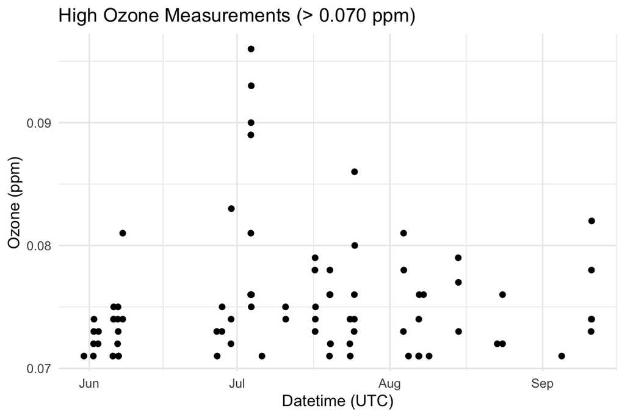

# Question 8: seasonality

Based on the time series, do you see any seasonal pattern for higher levels of ozone? Describe what you see.

June has a more consistent and dense results. In july the data disperses and never really goes back. As for the data, all of the data occurs in the summer, showing that ozones levels are higher in the summer, most likely related to the heat and weather.

# Question 9: proportion

What proportion of ozone measurements exceed the EPA guidelines? Instead of plugging in the actual values, make R figure out the length of each vector and the corresponding proportion in one line of code.

```
## # A tibble: 1 × 1
##   prop_exceed
##         <dbl>
## 1     0.00503
```

```
## [1] 0.005025423
```

# Question 10: `ggplot2` extensions

Navigate to [this website](https://exts.ggplot2.tidyverse.org/gallery/) and browse the `ggplot2` extensions. These themes can be very useful, so it’s good to be aware of them. Which theme would be appropriate for your own research or senior project, and why? How would you use it? Briefly describe your data and why the extension would improve the data visualization and communication.

For my senior project, I think using gganimate could be very useful. Part of my project will analyze data as the human body moves. Being able to see the changes in the data that correlate to the body would be very beneficial.

# Appendix

```r
# set global options for figures, code, warnings, and messages
knitr::opts_chunk$set(fig.width = 6, fig.height = 4, fig.path = "../figs/",
                      echo = FALSE, warning = FALSE, message = FALSE)
# load packages for current R session
library(tidyverse)
library(ggplot2)
# ozone: import, select, drop missing observations, rename
ftc <- read_csv("ftc_o3.csv")
ftc <- ftc %>%
  select(site_number, latitude, longitude,
  date_local, time_local, datetime, sample_measurement, units_of_measure,
  sample_duration, method)

ftc <- ftc %>%
  mutate(datetime = ymd_hms(datetime),
  ozone_ppm = sample_measurement)
ftc_clean <- ftc %>% filter(!is.na(ozone_ppm))

MW <- 47.998 # g/mol
T_c <- 10 # Celsius
temp_K <- 273.15 + T_c
P <- 637 # mmHg
R <- 22.4136 # (L*atm)/(mol*K)
ftc_clean <- ftc_clean %>%
  mutate(ozone_ugm3 = 1000 * ((ozone_ppm * MW * temp_K * P) / (R * (temp_K) *   P)))
ftc_clean %>% select(datetime, ozone_ppm, ozone_ppm, ozone_ugm3)
# examine dataframe object
summary(ftc_clean)
# create basic time series using ggplot2 package
# Q1: ggplot2 time series (geom_line is typical for dense time-series)
ggplot(ftc_clean, aes(x = datetime, y = ozone_ppm)) +
  geom_line(alpha = 0.5) +
  labs(title = "Hourly Ozone (ggplot2)",
       x = "Datetime (UTC)",
       y = "Ozone (ppm)") +
  theme_minimal()

# create base layer of ozone time series (no geom) and save to object

ozone_base <- ggplot(ftc_clean, aes(x = datetime, y = ozone_ppm))

ozone_base

# add layer to ggplot object
ozone_points <- ozone_base + geom_point(alpha = 0.35, size = 0.6)
ozone_points
# add theme to ggplot object
ozone_theme <- ozone_points + theme_minimal()
ozone_theme
# create new object with ggplot labels
ozone_labels <- labs(x = "Time of Measurement (YYYY-MM-DD HH:MM:SS)",
                     y = "Ozone Concentration (ppm)",
                     title = "Hourly Ozone Measurements in Fort Collins, CO")
ozone_labels <- labs(
  x = "Time of Measurement (UTC)",
  y = "Ozone Concentration (ppm)",
  title = "Hourly Ozone Measurements — Fort Collins, CO",
  subtitle = "Source: ftc_clean"
)


ozone_labeled <- ozone_theme + ozone_labels
ozone_labeled
# add alpha aesthetic to the geom_point()
ggplot(ftc_clean, aes(x = datetime, y = ozone_ppm)) +
  geom_point(alpha = 0.2, size = 0.5) +
  ozone_labels +
  theme_minimal()
# filter data to ozone concentration measurements exceeding 0.070 ppm
high_ozone <- ftc_clean %>% filter(ozone_ppm > 0.070)
ggplot(high_ozone, aes(x = datetime, y = ozone_ppm)) +
  geom_point() +
  labs(title = "High Ozone Measurements (> 0.070 ppm)",
       x = "Datetime (UTC)",
       y = "Ozone (ppm)") +
  theme_minimal()
# time series of high ozone measurements
# calculate proportion of ozone measurements that exceed 0.070 ppm
ftc_clean %>%
  summarize(prop_exceed = mean(ozone_ppm > 0.070, na.rm = TRUE))

mean(ftc_clean$ozone_ppm > 0.070, na.rm = TRUE)
```